# Forecasting Airbnb Stock Prices

Joshua Agbroko

## Dataset

#### Columns

- Date: The date of the trading day.
- Open: The opening price of the stock.
- High: The highest price of the stock during the trading day.
- Low: The lowest price of the stock during the trading day.
- Close: The closing price of the stock.
- Adj Close: The adjusted closing price of the stock.
- Volume: The volume of shares traded during the trading day.

```r
# loading required libraries  and dataset
library(tidyverse)
```

```r
library(ggplot2)
library(lubridate)
library(TTR)
library(zoo)
library(prophet)
library(xgboost)
library(reshape2)
airbnb_stock <- read_csv("abnb_stock_data.csv")
```

## Exploratory Data Analysis

#### Summary Statistics:

Computing summary statistics to understand the central tendency, dispersion, and shape of the data.

```r
summary(airbnb_stock)
```

```
##       Date                 Open             High             Low
##  Min.   :2020-12-10   Min.   : 82.97   Min.   : 84.25   Min.   : 81.91
##  1st Qu.:2021-09-30   1st Qu.:117.51   1st Qu.:119.70   1st Qu.:115.20
##  Median :2022-07-21   Median :139.25   Median :141.54   Median :136.54
##  Mean   :2022-07-20   Mean   :139.49   Mean   :142.57   Mean   :136.54
##  3rd Qu.:2023-05-10   3rd Qu.:159.50   3rd Qu.:164.70   3rd Qu.:155.70
##  Max.   :2024-02-29   Max.   :216.24   Max.   :219.94   Max.   :209.09
##      Close          Adj Close          Volume
##  Min.   : 82.49   Min.   : 82.49   Min.   : 1995400
##  1st Qu.:117.11   1st Qu.:117.11   1st Qu.: 4090600
##  Median :139.42   Median :139.42   Median : 5189000
##  Mean   :139.62   Mean   :139.62   Mean   : 6489790
##  3rd Qu.:160.25   3rd Qu.:160.25   3rd Qu.: 7136800
##  Max.   :216.84   Max.   :216.84   Max.   :74786400
```

#### Data Structure:

Examining the structure of the dataset to understand variable types and ensure they’re interpreted correctly.

```r
str(airbnb_stock)
```

```
## spc_tbl_ [809 × 7] (S3: spec_tbl_df/tbl_df/tbl/data.frame)
##  $ Date     : Date[1:809], format: "2020-12-10" "2020-12-11" ...
##  $ Open     : num [1:809] 146 147 135 127 126 ...
##  $ High     : num [1:809] 165 152 135 128 142 ...
##  $ Low      : num [1:809] 141 135 125 122 125 ...
##  $ Close    : num [1:809] 145 139 130 125 138 ...
##  $ Adj Close: num [1:809] 145 139 130 125 138 ...
##  $ Volume   : num [1:809] 70447500 26980800 16966100 10914400 20409600 ...
##  - attr(*, "spec")=
##   .. cols(
##   ..   Date = col_date(format = ""),
##   ..   Open = col_double(),
##   ..   High = col_double(),
##   ..   Low = col_double(),
##   ..   Close = col_double(),
##   ..   `Adj Close` = col_double(),
##   ..   Volume = col_double()
##   .. )
##  - attr(*, "problems")=<externalptr>
```

#### Time Series Visualization:

Create time series plots to visualize the trends, seasonality, and outliers in the data.

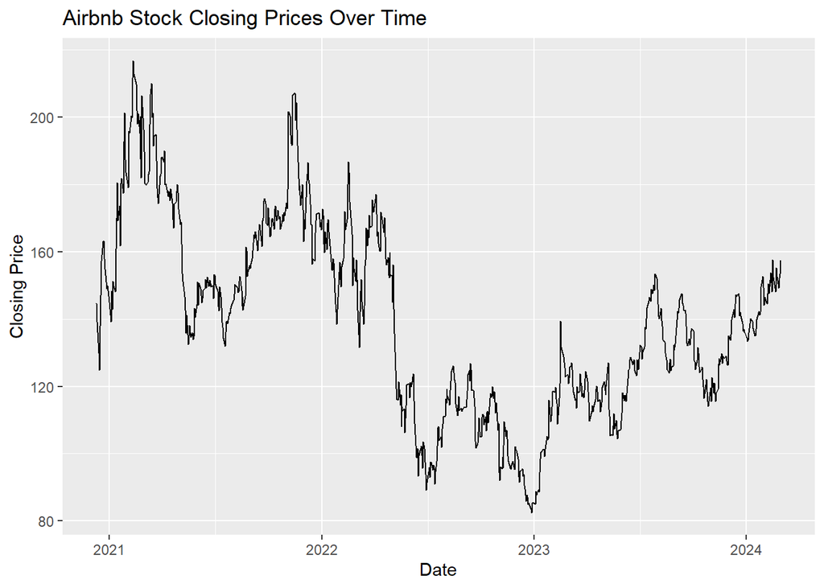

```r
# Time series plot of closing prices
ggplot(airbnb_stock, aes(x = Date, y = Close)) +
  geom_line() +
  labs(title = "Airbnb Stock Closing Prices Over Time",
       x = "Date", y = "Closing Price")
```

#### Exploring the distributions of numerical variables such as opening price, closing price, and volume traded.

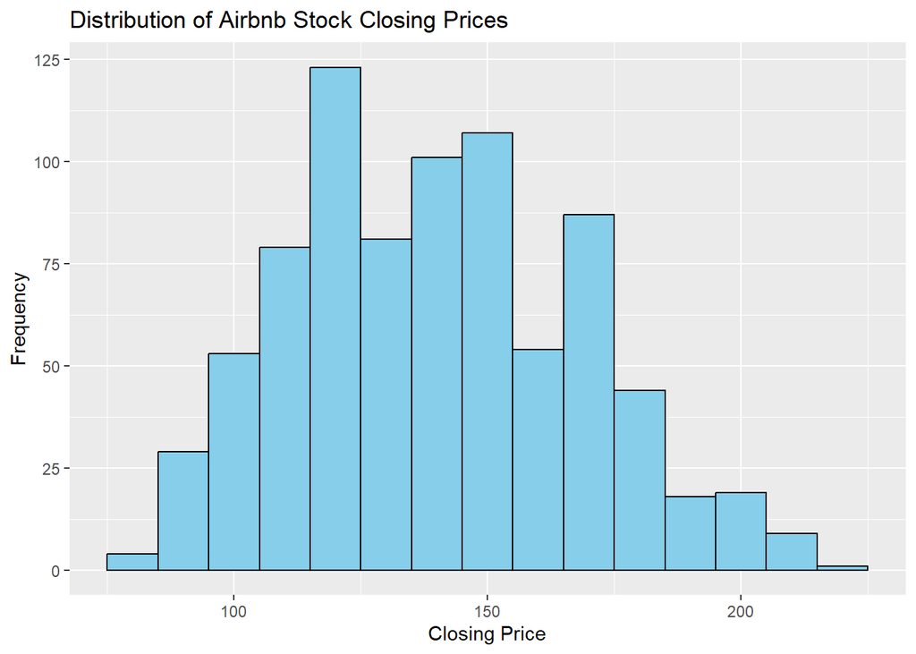

```r
# Histogram of closing prices
ggplot(airbnb_stock, aes(x = Close)) +
  geom_histogram(binwidth = 10, fill = "skyblue", color = "black") +
  labs(title = "Distribution of Airbnb Stock Closing Prices",
       x = "Closing Price", y = "Frequency")
```

The closing stock prices of airbnb seems to be majorly distributed between $120 - $150 over the past couple of years.

#### Identifying outliers and comparing the distribution of numerical variables across different categories

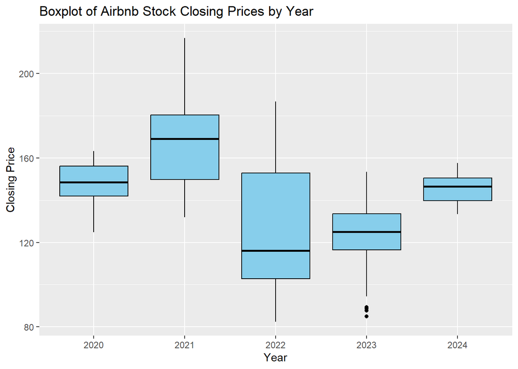

```r
# Boxplot of closing prices by year
ggplot(airbnb_stock, aes(x = factor(year(Date)), y = Close)) +
  geom_boxplot(fill = "skyblue", color = "black") +
  labs(title = "Boxplot of Airbnb Stock Closing Prices by Year",
       x = "Year", y = "Closing Price")
```

#### Correlation Analysis: Computing correlations between numerical variables to identify relationships.

```r
cor_matrix <- cor(select(airbnb_stock, -Date))
cor_matrix
```

```
##                  Open         High         Low      Close  Adj Close
## Open       1.00000000 0.9945360580  0.99463225  0.9889909  0.9889909
## High       0.99453606 1.0000000000  0.99281681  0.9950257  0.9950257
## Low        0.99463225 0.9928168134  1.00000000  0.9946864  0.9946864
## Close      0.98899089 0.9950256546  0.99468644  1.0000000  1.0000000
## Adj Close  0.98899089 0.9950256546  0.99468644  1.0000000  1.0000000
## Volume    -0.03438951 0.0009971324 -0.05025425 -0.0216807 -0.0216807
##                  Volume
## Open      -0.0343895106
## High       0.0009971324
## Low       -0.0502542540
## Close     -0.0216806976
## Adj Close -0.0216806976
## Volume     1.0000000000
```

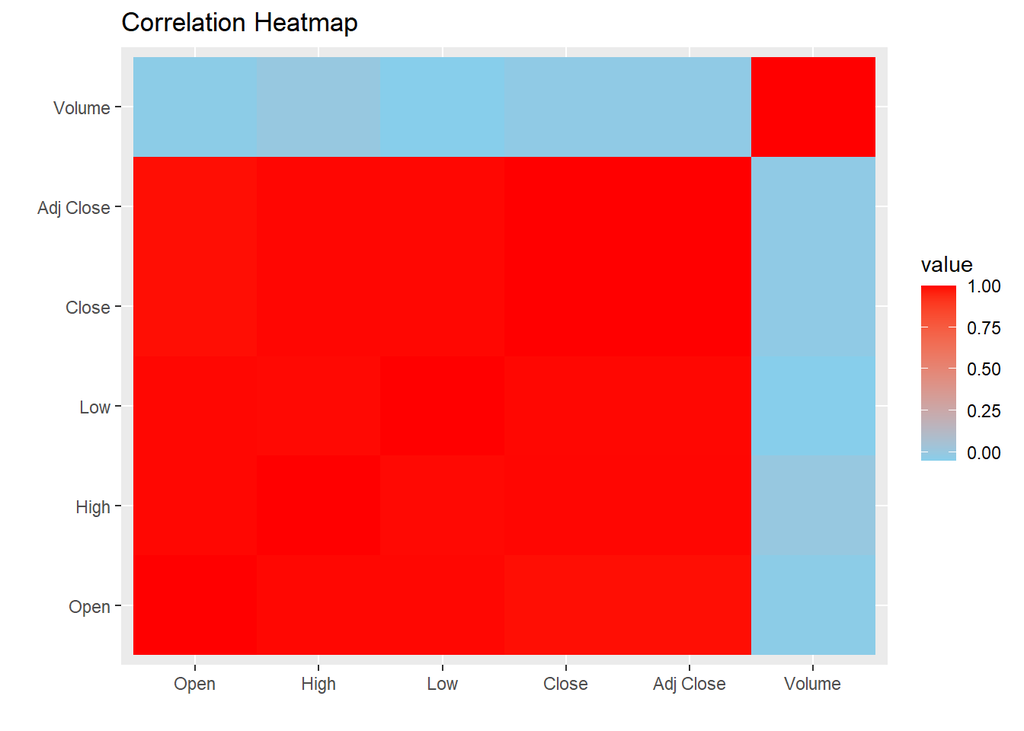

```r
# Heatmap of correlations
ggplot(data = melt(cor_matrix), aes(x = Var1, y = Var2, fill = value)) +
  geom_tile() +
  scale_fill_gradient(low = "skyblue", high = "red") +
  labs(title = "Correlation Heatmap", x = "", y = "")
```

## Feature Engineering

With a focus on trend analysis, seasonality analysis, and forecasting, feature engineering becomes crucial for extracting meaningful insights and building accurate forecasting models. Here are the feature engineering techniques we will be using:

- Date Features: Extracting additional date-related features from the ‘Date’ column that could capture seasonality and trends.
- Lag Features: Creating lag features to capture the historical behavior of stock prices. These features can help the model learn from past trends and patterns.
- Rolling Statistics: Calculating rolling statistics such as moving averages and standard deviations to smooth out noise and identify underlying trends.
- Price Differences: Computing price differences between consecutive days to capture daily changes in stock prices.
- Percentage Changes: Calculating percentage changes in stock prices to normalize the data and focus on relative changes rather than absolute values.
- Moving Averages: Computing various moving averages (i.e., simple moving average, exponential moving average) to identify trends and smooth out fluctuations in stock prices.
- Seasonal Dummy Variables: Creating dummy variables to represent different seasons or quarters if seasonality exhibits significant variation across different periods of the year.

```r
### Date features
#### Converting 'Date' column to Date format

airbnb_stock$Date <- as.Date(airbnb_stock$Date)

#### Extracting year, month, quarter, and day of the week
airbnb_stock$Year <- year(airbnb_stock$Date)
airbnb_stock$Month <- month(airbnb_stock$Date)
airbnb_stock$Quarter <- quarter(airbnb_stock$Date)
airbnb_stock$DayOfWeek <- weekdays(airbnb_stock$Date)

### Lag features
#### Create lagged features for closing prices and volume
airbnb_stock$Lag1_Close <- lag(airbnb_stock$Close)
airbnb_stock$Lag2_Close <- lag(airbnb_stock$Close, 2)
airbnb_stock$Lag1_Volume <- lag(airbnb_stock$Volume)
airbnb_stock$Lag2_Volume <- lag(airbnb_stock$Volume, 2)

### Rolling Statistics
#### Calculate rolling mean of closing prices over a 7-day window
airbnb_stock$Rolling_Mean_Close <- rollmean(airbnb_stock$Close, k = 7, fill = NA)
#### Calculate rolling standard deviation of closing prices over a 7-day window
airbnb_stock$Rolling_SD_Close <- rollapply(airbnb_stock$Close, width = 7, FUN = sd, fill = NA)


### Price Differences
#### Calculate price difference between today's closing price and yesterday's closing price
airbnb_stock$Price_Diff <- c(NA, diff(airbnb_stock$Close))

### Percentage Changes
# Calculating percentage change in closing price from the previous day
airbnb_stock <- airbnb_stock %>%
  mutate(Percent_Change = c(NA, diff(Close) / lag(Close))[-1])

### moving Averages
#### Calculate simple moving average of closing prices over a 7-day window
airbnb_stock$SMA_7 <- SMA(airbnb_stock$Close, n = 7)

#### Calculate exponential moving average of closing prices over a 7-day window
airbnb_stock$EMA_7 <- EMA(airbnb_stock$Close, n = 7)

### seasonal dummy variables
#### Creating dummy variables for quarters (example)
airbnb_stock$Q1 <- ifelse(airbnb_stock$Quarter == 1, 1, 0)
airbnb_stock$Q2 <- ifelse(airbnb_stock$Quarter == 2, 1, 0)
airbnb_stock$Q3 <- ifelse(airbnb_stock$Quarter == 3, 1, 0)
airbnb_stock$Q4 <- ifelse(airbnb_stock$Quarter == 4, 1, 0)
```

## Trend Analysis

Trend analysis involves examining the overall direction and pattern of changes in a dataset over time. In the context of Airbnb stock data, trend analysis will help us identify long-term trends in stock prices. By performing trend analysis, you’ll gain insights into the overall behavior of Airbnb stock prices over time, which can inform forecasting models and investment decisions.

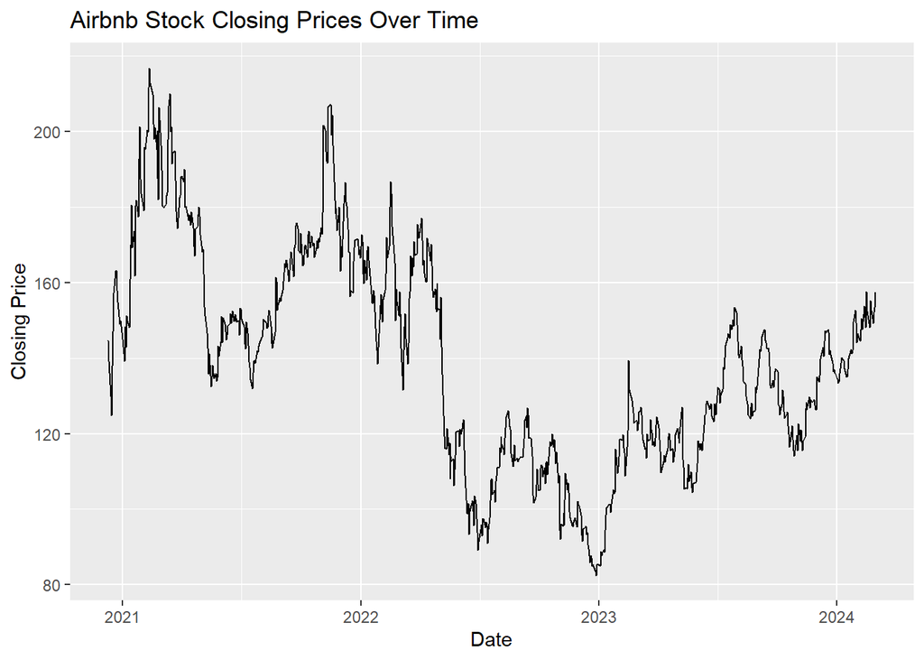

```r
### Plotting closing prices over time
## Time series plot of closing prices
ggplot(airbnb_stock, aes(x = Date, y = Close)) +
  geom_line() +
  labs(title = "Airbnb Stock Closing Prices Over Time",
       x = "Date", y = "Closing Price")
```

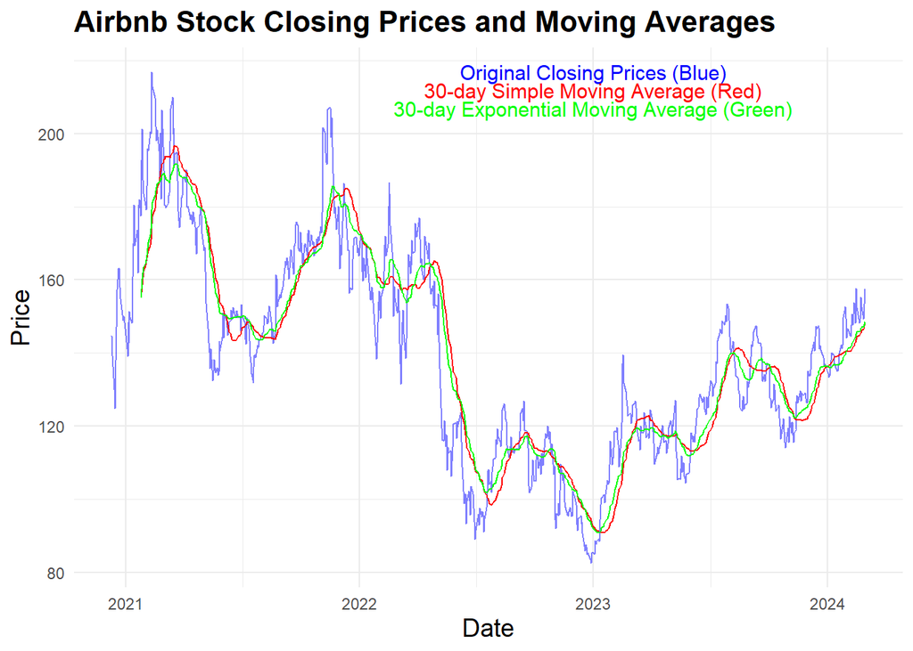

```r
### Plotting Moving averages
# Calculate 30-day simple moving average (SMA)
airbnb_stock$SMA_30 <- SMA(airbnb_stock$Close, n = 30)

# Calculate 30-day exponential moving average (EMA)
airbnb_stock$EMA_30 <- EMA(airbnb_stock$Close, n = 30)

# Plot closing prices and moving averages
ggplot(airbnb_stock, aes(x = Date)) +
  geom_line(aes(y = Close), color = "blue", alpha = 0.5) +
  geom_line(aes(y = SMA_30), color = "red") +
  geom_line(aes(y = EMA_30), color = "green") +
  labs(title = "Airbnb Stock Closing Prices and Moving Averages",
       x = "Date", y = "Price") +
  scale_color_manual(values = c("blue", "red", "green"),
                     labels = c("Close", "SMA(30)", "EMA(30)")) +
  theme_minimal() +
  theme(plot.title = element_text(size = 16, face = "bold"),
        axis.title = element_text(size = 14),
        legend.title = element_text(size = 12),
        legend.text = element_text(size = 10)) +
  annotate("text", x = as.Date("2023-01-01"), y = max(airbnb_stock$Close),
           label = "Original Closing Prices (Blue)", color = "blue", size = 4) +
  annotate("text", x = as.Date("2023-01-01"), y = max(airbnb_stock$Close) - 5,
           label = "30-day Simple Moving Average (Red)", color = "red", size = 4) +
  annotate("text", x = as.Date("2023-01-01"), y = max(airbnb_stock$Close) - 10,
           label = "30-day Exponential Moving Average (Green)", color = "green", size = 4)
```

## Seasonality Analysis

Seasonality analysis involves identifying and analyzing recurring patterns or fluctuations in a dataset that occur at regular intervals, such as daily, weekly, monthly, or yearly cycles. In the context of Airbnb stock data, seasonality analysis can help us understand if there are any consistent seasonal trends in stock prices.

### Visualizing Seasonal Patterns:

We’ll Start by visualizing the average closing prices for each day of each month and each quarter to identify any recurring patterns.

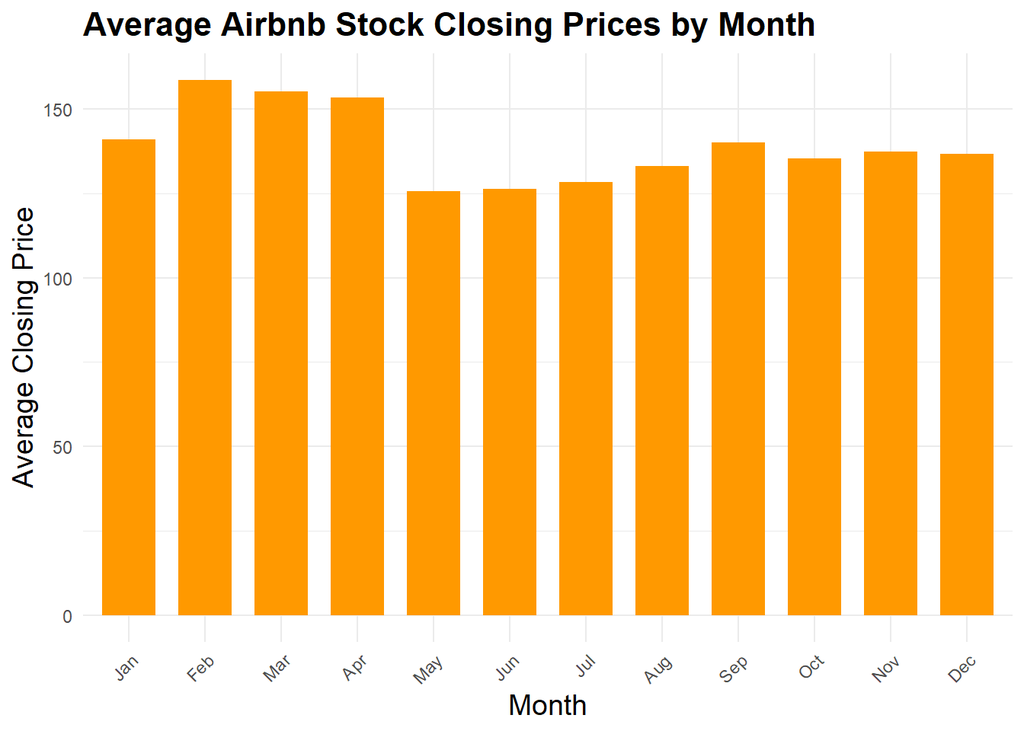

```r
### Extracting the month from Date
airbnb_stock$Month <- month(airbnb_stock$Date, label = TRUE)

# Calculating the average closing prices for each month
avg_price_by_month <- airbnb_stock %>%
  group_by(Month) %>%
  summarize(Avg_Close = mean(Close, na.rm = TRUE))

# Plotting the average closing prices by month
ggplot(avg_price_by_month, aes(x = Month, y = Avg_Close, fill = Month)) +
  geom_bar(stat = "identity", width = 0.7) +
  labs(title = "Average Airbnb Stock Closing Prices by Month",
       x = "Month", y = "Average Closing Price") +
  scale_fill_manual(values = rep(c("#FF9900", "#FF9900", "#FF9900", "#FF9900", "#FF9900", "#FF9900", "#FF9900", "#FF9900", "#FF9900", "#FF9900", "#FF9900", "#FF9900"), 2),
                    guide = FALSE) +  # Custom color palette for months
  theme_minimal() +
  theme(plot.title = element_text(size = 16, face = "bold"),
        axis.title = element_text(size = 14),
        axis.text.x = element_text(angle = 45, hjust = 1))
```

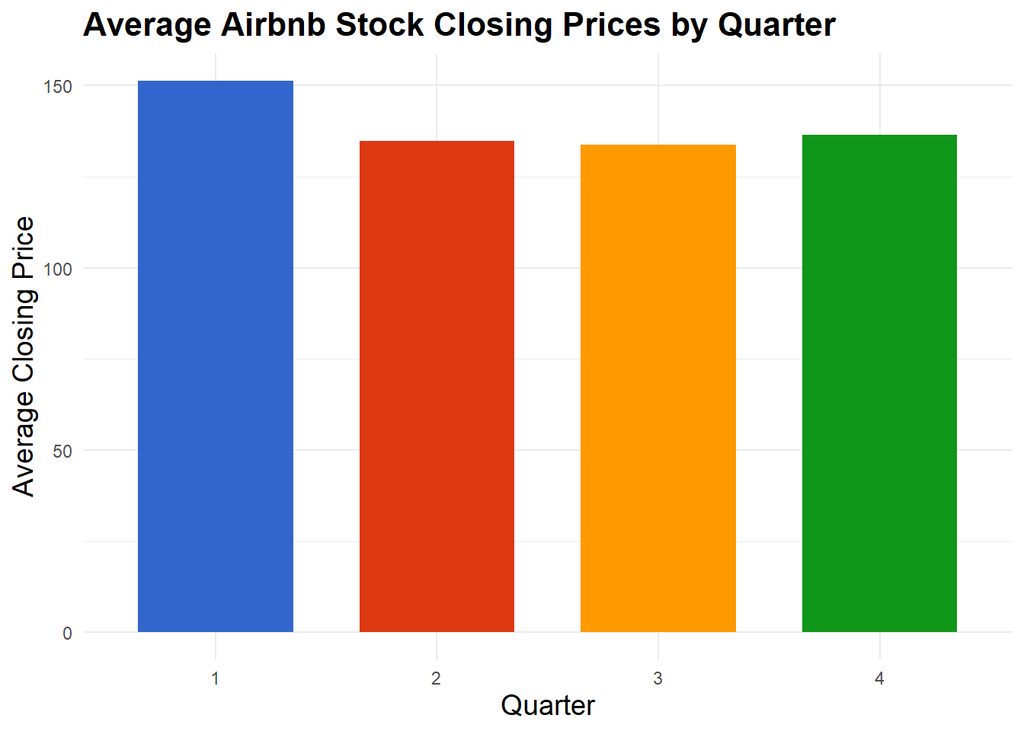

```r
# Extract quarter from Date
airbnb_stock$Quarter <- quarter(airbnb_stock$Date)

# Calculate average closing prices for each quarter

avg_price_by_quarter <- airbnb_stock %>%
  group_by(Quarter) %>%
  summarize(Avg_Close = mean(Close, na.rm = TRUE))

# Plot average closing prices by quarter
ggplot(avg_price_by_quarter, aes(x = factor(Quarter), y = Avg_Close, fill = factor(Quarter))) +
  geom_bar(stat = "identity", width = 0.7) +
  labs(title = "Average Airbnb Stock Closing Prices by Quarter",
       x = "Quarter", y = "Average Closing Price") +
  scale_fill_manual(values = rep(c("#3366CC", "#DC3912", "#FF9900", "#109618"), 2),
                    guide = FALSE) +  # Custom color palette for quarters
  theme_minimal() +
  theme(plot.title = element_text(size = 16, face = "bold"),
        axis.title = element_text(size = 14),
        axis.text.x = element_text(angle = 0, hjust = 0.5))
```

## Forecasting the Airbnb Stock Prices for the next Year

```r
# Preparing data in Prophet format
#### Converting 'Date' column to a time series object

data_prophet <- data.frame(ds = airbnb_stock$Date, y = airbnb_stock$Close)

# Fitting Prophet model
prophet_model <- prophet(data_prophet)
```

```
## Disabling daily seasonality. Run prophet with daily.seasonality=TRUE to override this.
```

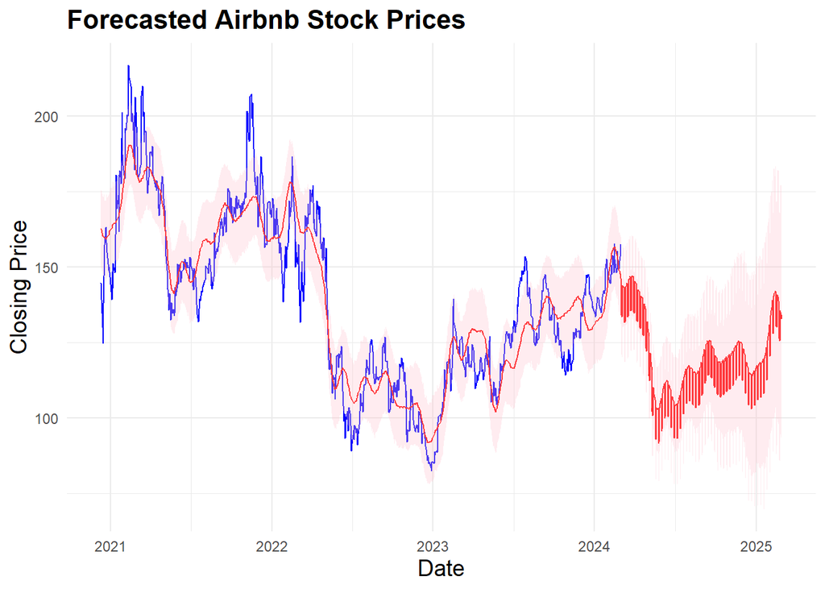

```r
# Making future dataframe for forecasting (i.e., next 365 days)
future <- make_future_dataframe(prophet_model, periods = 365)

# Forecast future values
prophet_forecast <- predict(prophet_model, future)

# Convert forecast data to a dataframe
prophet_forecast_df <- data.frame(ds = prophet_forecast$ds, yhat = prophet_forecast$yhat, yhat_lower = prophet_forecast$yhat_lower, yhat_upper = prophet_forecast$yhat_upper)
prophet_forecast_df$ds <- as.Date(prophet_forecast_df$ds)

# Plot historical data and forecast with prediction intervals using ggplot2
ggplot() +
  geom_line(data = airbnb_stock, aes(x = Date, y = Close), color = "blue") +
  geom_line(data = prophet_forecast_df, aes(x = ds, y = yhat), color = "red") +
  geom_ribbon(data = prophet_forecast_df, aes(x = ds, ymin = yhat_lower, ymax = yhat_upper), fill = "pink", alpha = 0.3) +
  labs(title = "Forecasted Airbnb Stock Prices",
       x = "Date", y = "Closing Price") +
  theme_minimal() +
  theme(plot.title = element_text(size = 16, face = "bold"),
        axis.title = element_text(size = 14))
```

```r
## Evaluation of the forecasted model
# Calculate evaluation metrics
prophet_mae <- mean(abs(prophet_forecast_df$yhat - airbnb_stock$Close))
prophet_mse <- mean((prophet_forecast_df$yhat - airbnb_stock$Close)^2)
prophet_rmse <- sqrt(mean((prophet_forecast_df$yhat - airbnb_stock$Close)^2))
prophet_mape <- mean(abs((prophet_forecast_df$yhat - airbnb_stock$Close) / airbnb_stock$Close)) * 100
```